# eda

Brenwin

24/07/2021

# Read in data

```r
# --- read in raw data
data <- readxl::read_xlsx("data/ANZ synthesised transaction dataset.xlsx")
# --- `data_explore`
data_explore <- data
```

- 12,043 rows (transactions) for 100 customers (one bank `account` each)
- 01/08/2018 - 31/10/2018 (92 days duration)
  - only 91 unique dates in data set (transaction record for 1 day missing; on 16/08/2018)

# visualise missing data: `naniar::vis_miss`

```r
data_explore %>%
  naniar::vis_miss(cluster = T)
```

[output not shown]

- some columns contain missing data; likely due to nature of transaction
  - e.g. merchants; not involved in Interbank transfers or salary payment

# identify annual salary for each customer; join with data

```r
# --- annual salary
annual_sal <- data_explore %>%
  filter(txn_description == "PAY/SALARY") %>%
  group_by(account) %>%
  summarise(annual_sal = (sum(amount)/3) * 12)
```

annual salary for each customer: $12\times(avg.\ income\ over\ the\ 3\ months)$

```r
data_explore <- left_join(data_explore, annual_sal,
                          by = "account")
```

### plot annual salary of each customer

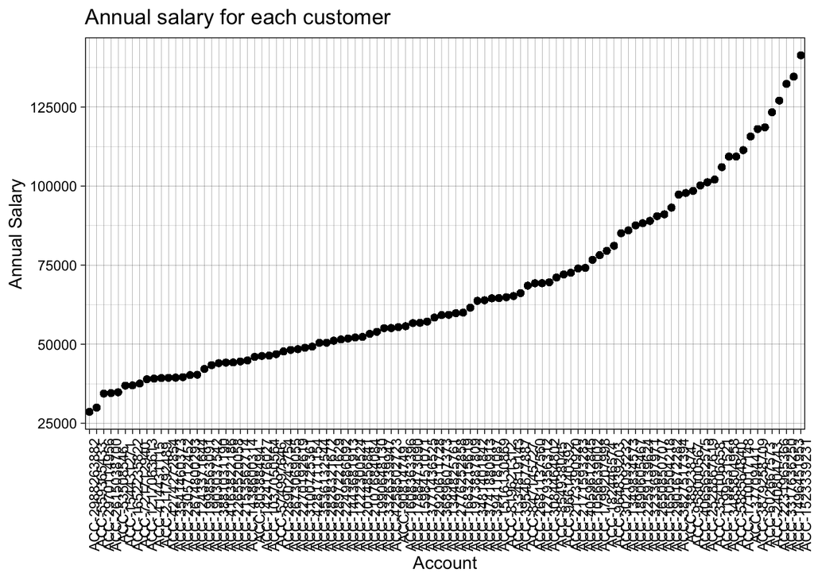

```r
# --- plot annual salary for each customer
data_explore %>%
  ggplot() +
  geom_point(aes(x = forcats::fct_reorder(account, annual_sal),
                 y = annual_sal)) +
  theme_linedraw() +
  theme(axis.text.x = element_text(angle = 90)) +
  ggtitle("Annual salary for each customer") +
  labs(y = "Annual Salary",
       x = "Account")
```

### five number summary of customers’ salary

```r
# --- annual salary 5-number summary
data_explore %>%
  select(annual_sal) %>%
  summary()
```

```
##    annual_sal
##  Min.   : 28624
##  1st Qu.: 48858
##  Median : 59810
##  Mean   : 68702
##  3rd Qu.: 85992
##  Max.   :141376
```

# Explore correlations between annual salary & various customer attributes(variables)

- attributes could be those available or derived
  - those; relevant to salary

```r
# remove attributes (variables); unrelated to annual salary
data_explore2 <- data_explore %>%
  select(-status, -card_present_flag, -bpay_biller_code, # binary values
         -currency, # all AUD
         -merchant_id, -merchant_code, -merchant_long_lat, # nothing to do with merchants
         -first_name, # character type
         -merchant_suburb, -merchant_state, # nothing to do with merchants
         -extraction, # date & time irrelevant
         -transaction_id, # irrelevant
         -customer_id, # irrelevant
         -country) # all in AUS
```

```r
# --- separate `long_lat` into 2 columns `lon` & `lat`
data_explore2 <- data_explore2 %>%
  tidyr::separate(col = long_lat,
                  sep = " -",
                  into = c("lon", "lat")) %>%
  # turn `lon` & `lat`; into numeric
  mutate(lon = as.numeric(lon),
         lat = as.numeric(lat))
```

- attributes include
  - `lat`, `lon`
  - `txn_description` *to derive purchasing behaviour
  - `balance`
  - customer attributes: `gender`, `age`
  - miscs: `date`, `amount`, `movement`

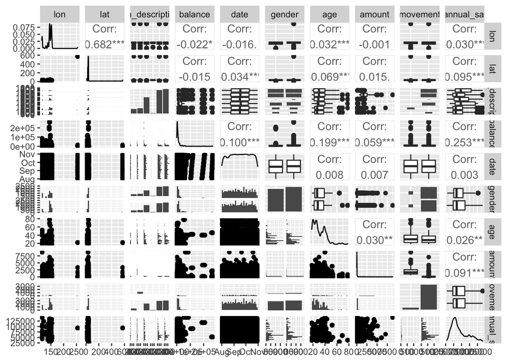

```r
data_explore2[,-1] %>%
  GGally::ggpairs()
```

## `annual_sal` vs. `age`

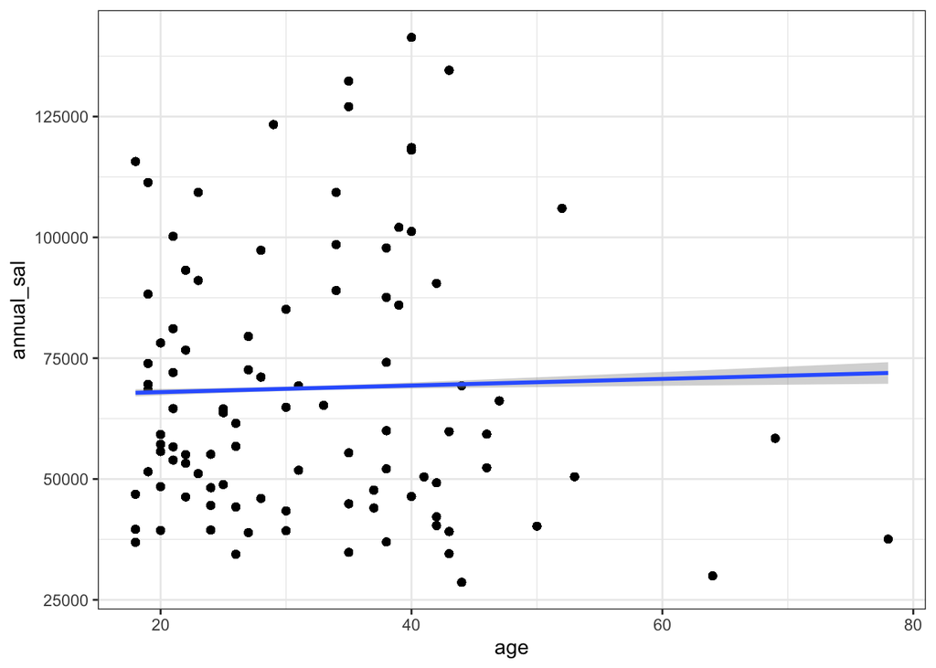

```r
data_explore2 %>%
  ggplot(aes(x = age,
             y = annual_sal)) +
  geom_point() +
  geom_smooth(method = "lm") +
  colorspace::scale_color_discrete_qualitative() +
  theme_bw()
```

- one might expect a linear r/s; but none observed
  - number of customers particularly after about 40 years of age seem to deviate from the trend

## `annual_sal` vs. `balance`

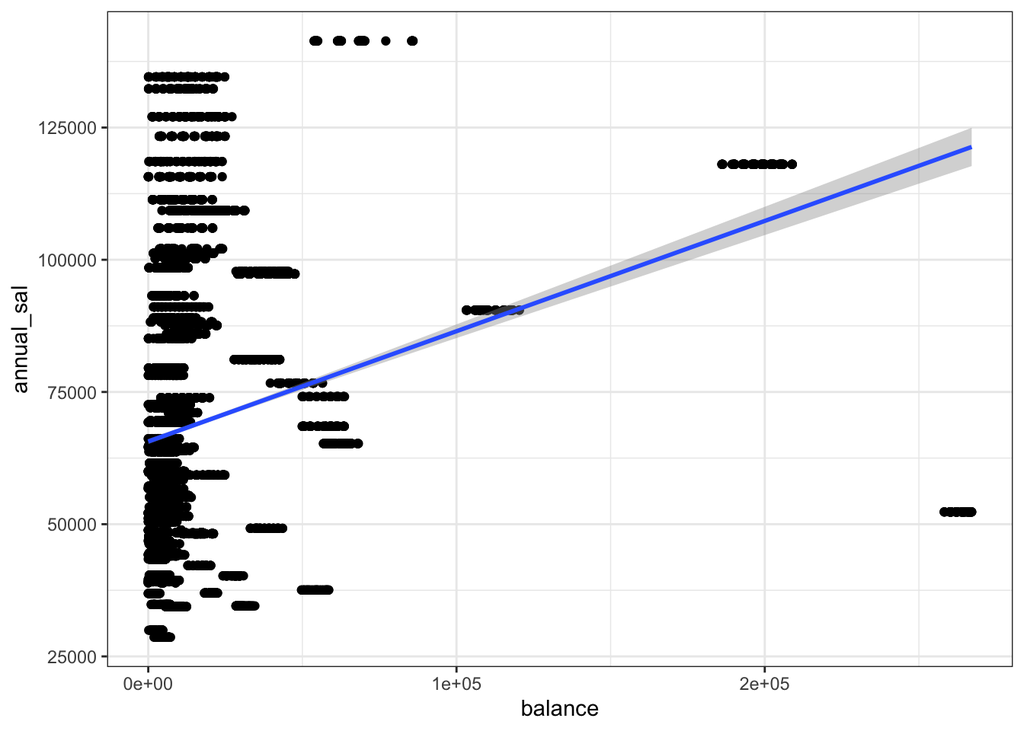

```r
data_explore2 %>%
  ggplot(aes(x = balance,
             y = annual_sal)) +
  geom_point() +
  geom_smooth(method = "lm") +
  theme_bw()
```

- a linear r/s might not be appropriate

## `annual_sal` vs. `lon` & `lat`

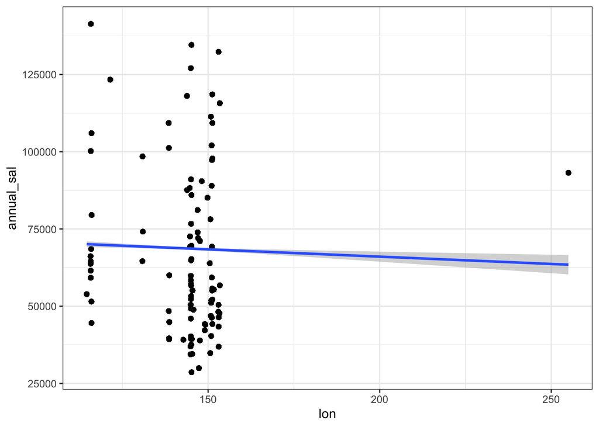

```r
# `annual_sal` vs. `lon`
data_explore2 %>%
  ggplot(aes(x = lon,
             y = annual_sal)) +
  geom_point() +
  geom_smooth(method = "lm") +
  theme_bw()
```

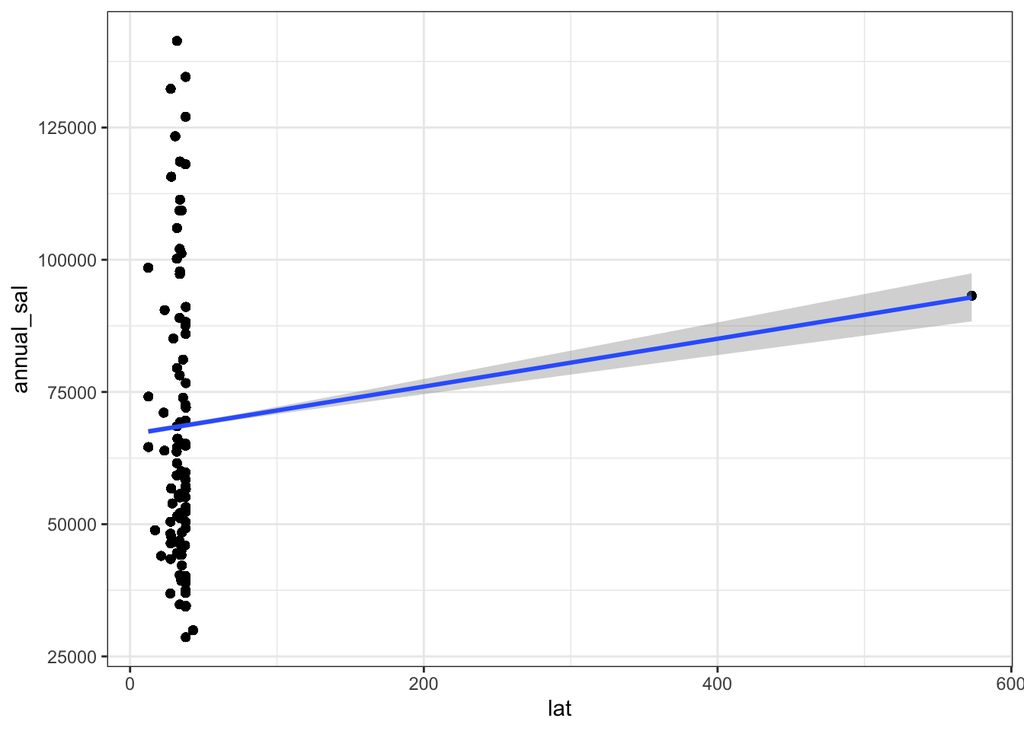

```r
# `annual_sal` vs. `lat`
data_explore2 %>%
  ggplot(aes(x = lat,
             y = annual_sal)) +
  geom_point() +
  geom_smooth(method = "lm") +
  theme_bw()
```

- not much r/s can be gleaned for `annual_sal` and `lat` & `lon`
  - linear assumption might not be appropriate

## `annual_sal` vs. purchasing behaviour

```r
# --- filtering out purchase transactions
data_purchase <- data_explore %>%
  filter(txn_description %in% c("POS", "SALES-POS"))
  # filter(merchant_id != "") # purchase transactions; must be associated with merchant

data_purchase <- data_purchase %>%
  group_by(account) %>%
  mutate(total_spend = sum(amount), # total spending: total purchase transactions amount
         total_spend_vol = n()) %>% # total spending volume: number of purchase transactions
  distinct(account,
           .keep_all = T)
```

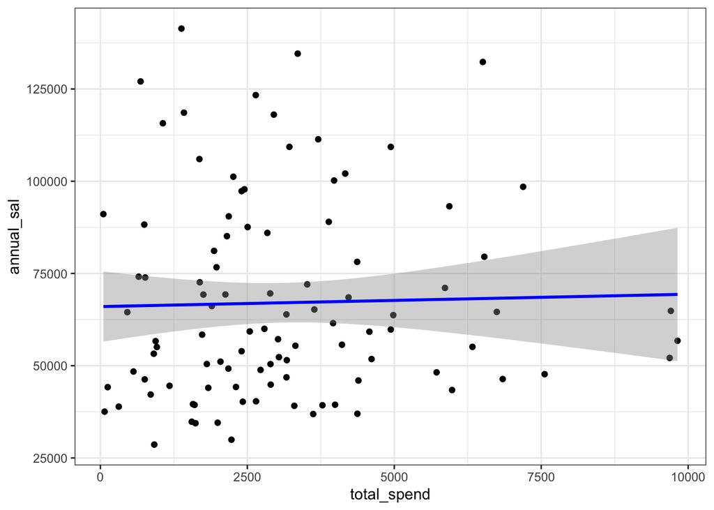

```r
# higher annual salary, higher purchase transaction amt.?
data_purchase %>%
  ggplot(aes(x = total_spend,
             y = annual_sal)) +
  geom_point() +
  # add smooth line
  geom_smooth(method = "lm",
              colour = "blue",
              se = T) +
  theme_bw()
```

- one might hypothesise that `total_spend` increases with `annual_sal` but that does not seem the case
  - i.e. hypothesis that higher salary beget higher spendings proves incorrect
  - considerable number of outliers

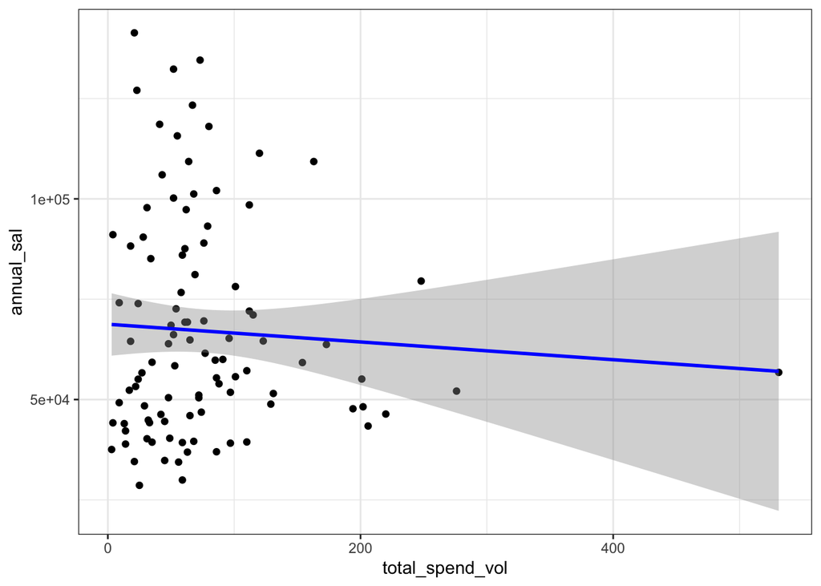

```r
# higher annual salary, higher purchase transaction volume?
data_purchase %>%
  ggplot(aes(x = total_spend_vol,
             y = annual_sal)) +
  geom_point() +
  # add smooth line
  geom_smooth(method = "lm",
              colour = "blue",
              se = T) +
  theme_bw()
```

- linear assumption may not be appropriate
- as `total_spend_vol` increases `annual_sal` seem to dip slightly; althought not very clear
  - high deviation

## `annual_sal` vs. `gender` boxplot

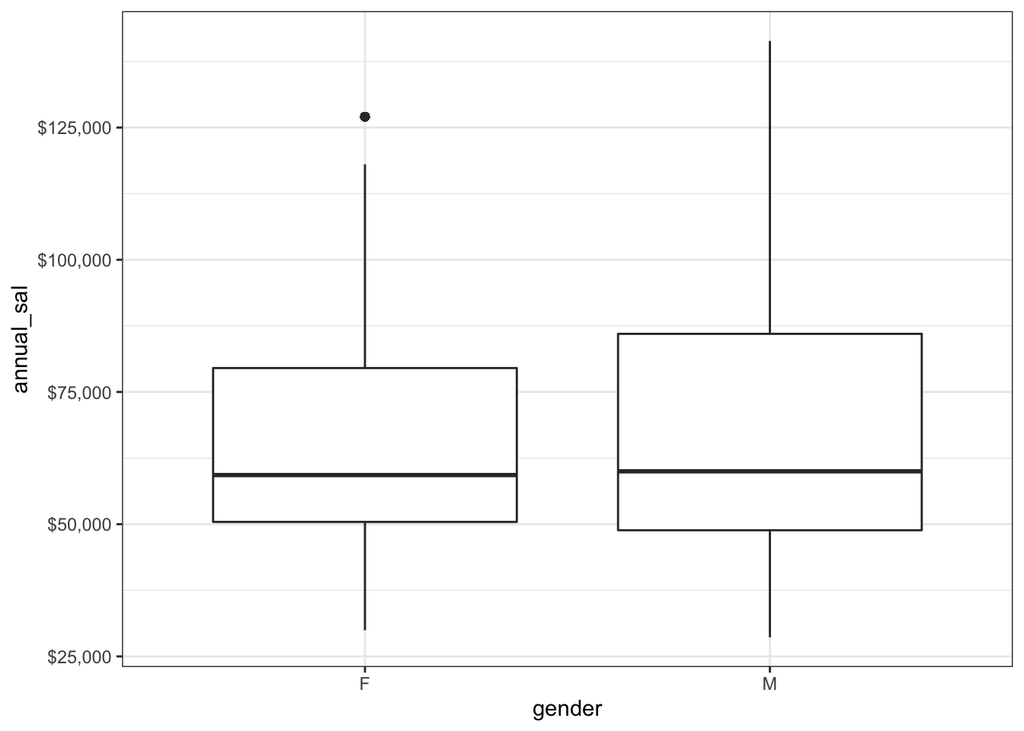

```r
data_explore2 %>%
  ggplot(aes(x = gender,
             y = annual_sal)) +
  geom_boxplot() +
  theme_bw() +
  scale_y_continuous(labels = scales::dollar_format())
```

- on average, men earned a slightly more than females

# build simple regression model; predict annual salary for each customer; using attributes above

- covariates
  - `age`
  - `gender`
  - `balance`
  - `lon`
  - `lat`
  - `total_spend`
  - `total_spend_vol`

```r
# --- join data with purchase data
model_data <- data_purchase %>%
  select(account, total_spend, total_spend_vol) %>%
  right_join(data_explore2) %>%
  ungroup() %>%
  select(-txn_description, -date, -movement, -amount, -account)
# --- fit linear regression model
fit_lm <- stats::lm(annual_sal ~ total_spend + total_spend_vol + lon + lat + balance + gender + age,
                    data = model_data)

summary(fit_lm)
```

```
##
## Call:
## stats::lm(formula = annual_sal ~ total_spend + total_spend_vol +
##     lon + lat + balance + gender + age, data = model_data)
##
## Residuals:
##    Min     1Q Median     3Q    Max
## -67017 -15917  -7685  11712  68117
##
## Coefficients:
##                   Estimate Std. Error t value Pr(>|t|)
## (Intercept)      9.931e+04  2.553e+03  38.904   <2e-16 ***
## total_spend      2.314e-01  1.619e-01   1.429   0.1530
## total_spend_vol -3.257e+01  3.638e+00  -8.953   <2e-16 ***
## lon             -2.258e+02  1.912e+01 -11.808   <2e-16 ***
## lat              8.780e+01  5.783e+00  15.182   <2e-16 ***
## balance          1.919e-01  7.372e-03  26.030   <2e-16 ***
## genderM          5.631e+02  4.734e+02   1.190   0.2343
## age             -5.505e+01  2.329e+01  -2.363   0.0181 *
## ---
## Signif. codes:  0 '***' 0.001 '**' 0.01 '*' 0.05 '.' 0.1 ' ' 1
##
## Residual standard error: 24570 on 12035 degrees of freedom
## Multiple R-squared:  0.1045, Adjusted R-squared:  0.104
## F-statistic: 200.7 on 7 and 12035 DF,  p-value: < 2.2e-16
```

### is above model accurate? Should ANZ use it to segment customers (for whom it does not have this data) into income brackets for reporting purposes?

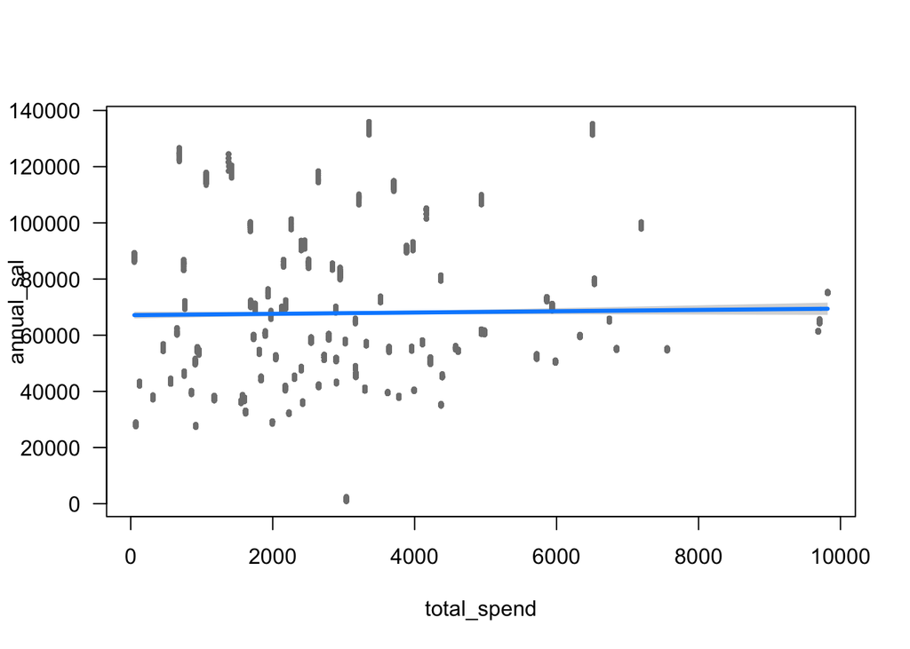

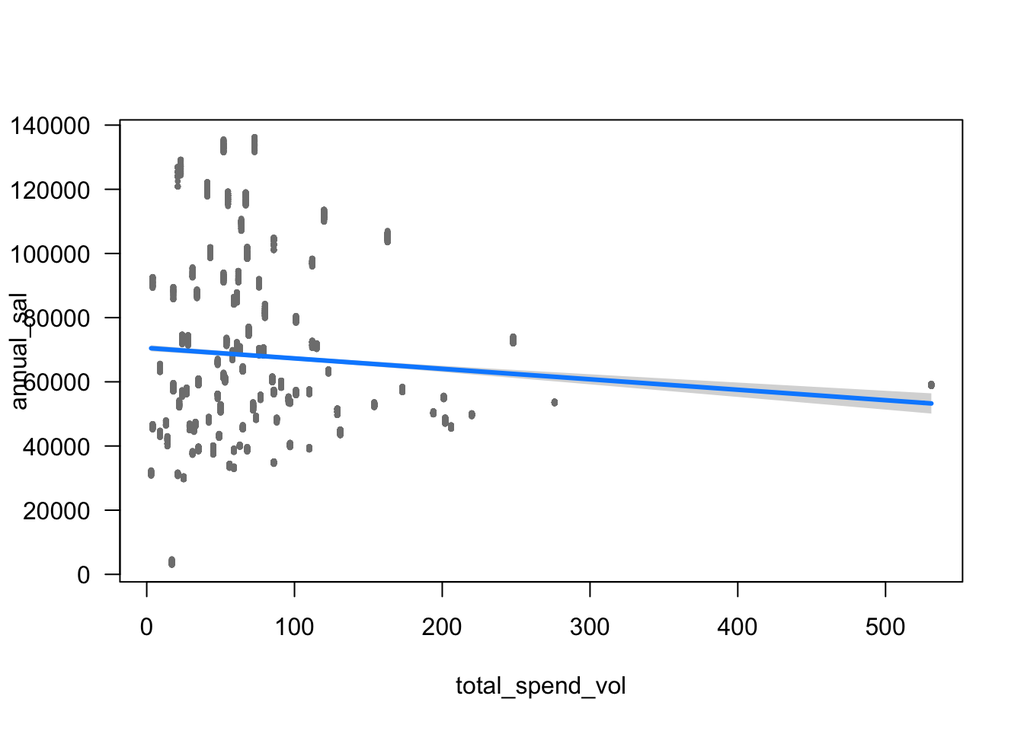

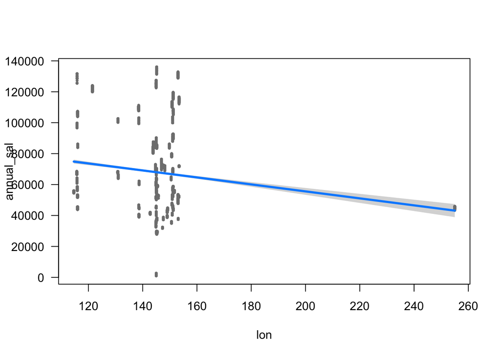

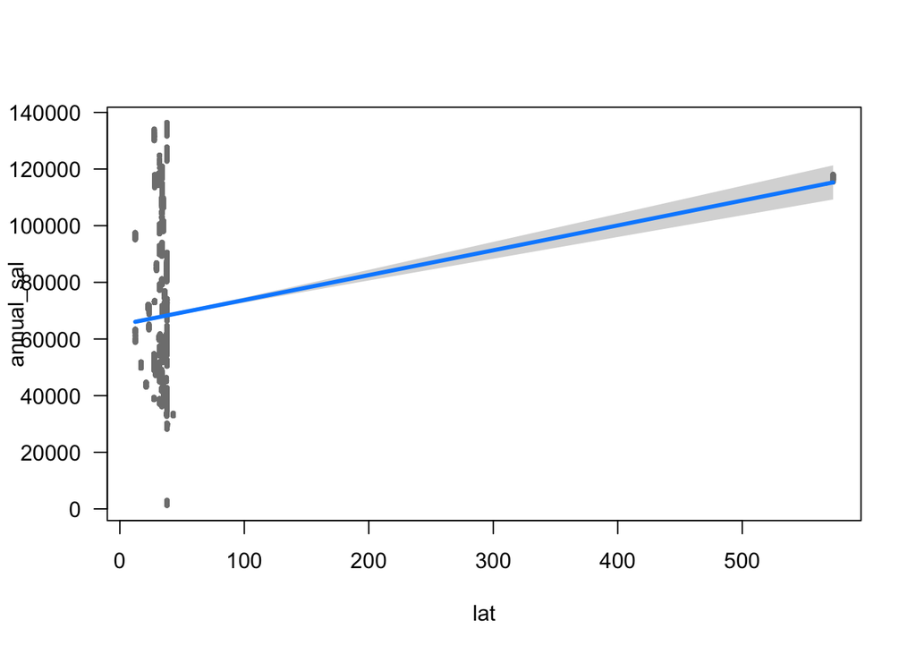

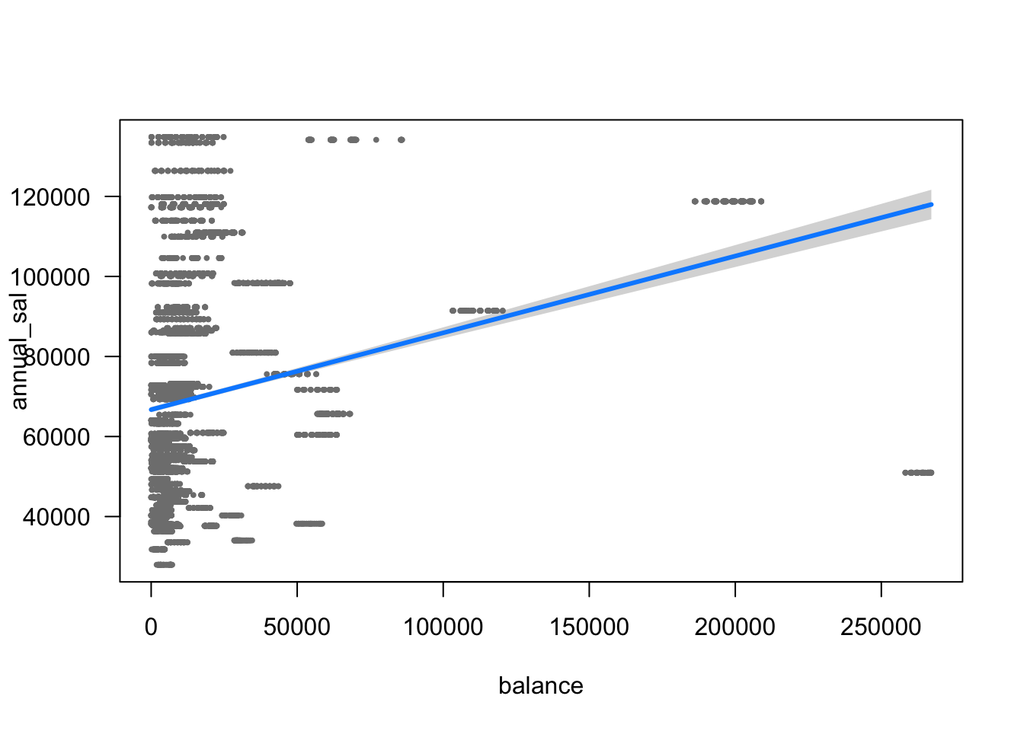

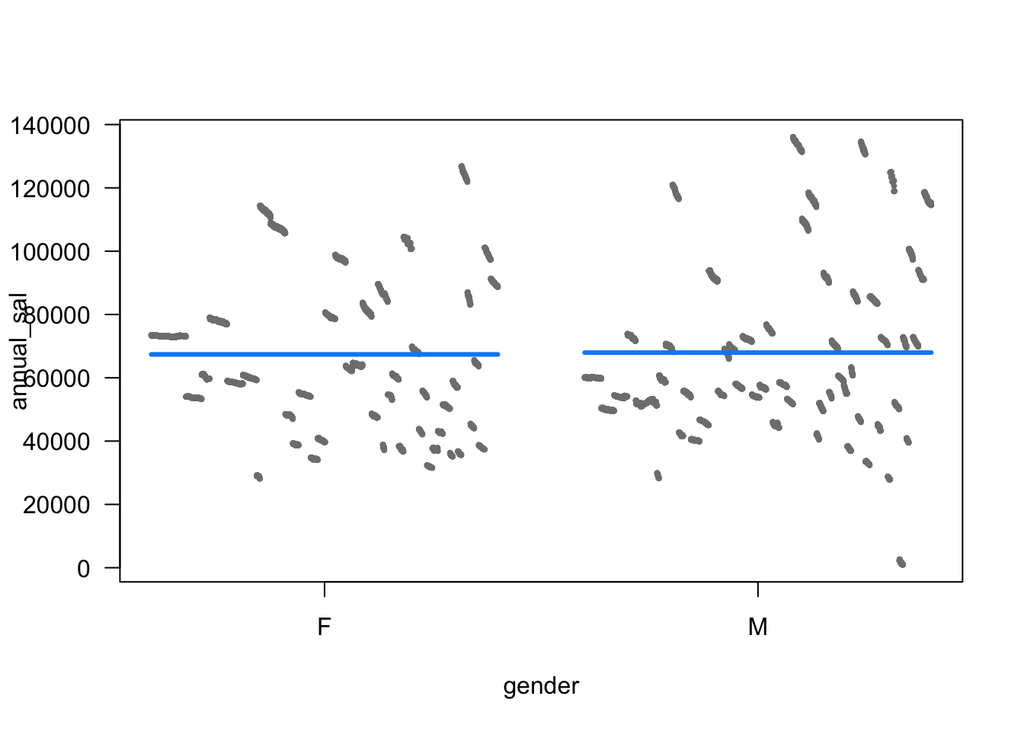

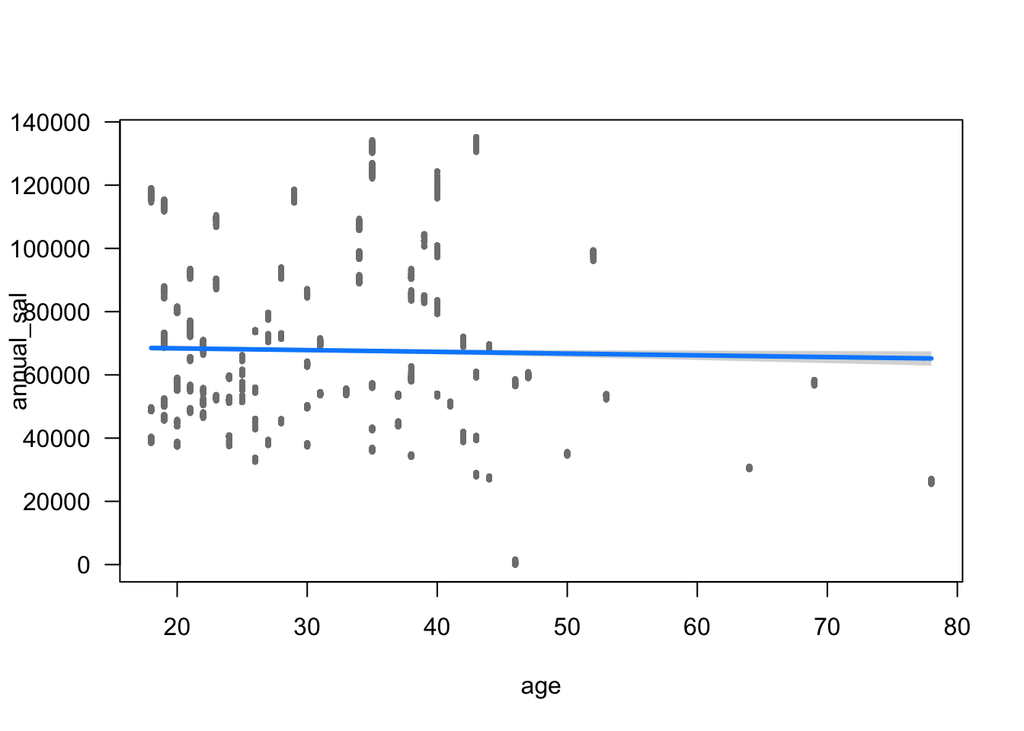

```r
fit_lm %>%
  visreg::visreg()
```

- The above regression model has an $adj.\ R^2$ value of $0.104$ which implies the model is not very accurate.
- As can be observed in the partial residual plots above, the linear r/s is not that strong across most of not all the covariates.
  - This is to say even for customers with similar annual salary, their attributes and purchasing behaviour can vary widely — hence ANZ should NOT segment customers into income brackets for reporting purposes

# for a challenge: build a decision-tree based model to predict salary. does it perform better? how would you accurately test the performance of this model?

```r
# --- model specification: regression tree
rpart_mod <- parsnip::decision_tree() %>%
  set_engine("rpart") %>% # set computational engine
  set_mode("regression") %>% # set model mode: regression *instead of classification
  translate() # translate model specification; into code object; specific to particular engine (R package)

# --- fit the regression tree
fit_tree <- rpart_mod %>%
  parsnip::fit(annual_sal ~ total_spend + total_spend_vol + lon + lat + balance + gender + age,
               data = model_data)
```

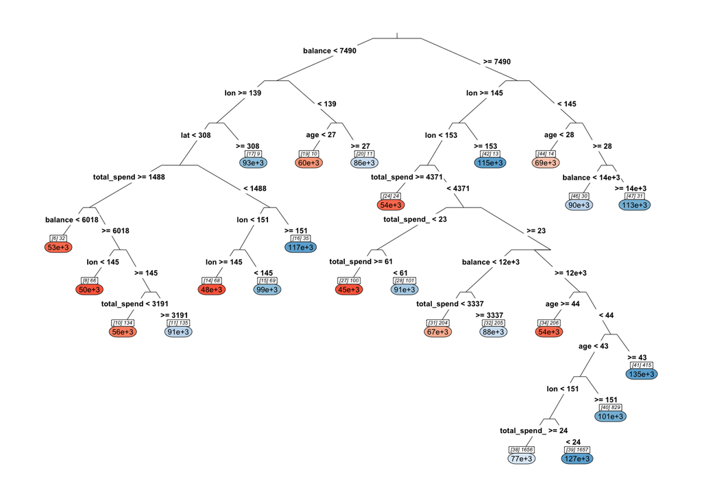

```r
# --- plot rpart model
rpart.plot::prp(fit_tree$fit,
                type = 3, # draw separate split labels; for left & right directions
                ni = T, # display node indeces
                nn = T, # display node numbers
                box.palette = "RdBu") # palette to colour node boxes
```